# Calculating statistics

Jeff Leek

## Dependencies

This document depends on the following packages:

```r
  library(devtools)
  library(Biobase)
  library(limma)
  library(edge)
  library(genefilter)
```

To install these packages you can use the code (or if you are compiling the document, remove the `eval=FALSE` from the chunk.)

```r
install.packages(c("devtools"))
source("http://www.bioconductor.org/biocLite.R")
biocLite(c("Biobase","limma","genefilter","jdstorey/edge"))
```

## Download the data

Here we are going to use some data from the paper [Evaluating gene expression in C57BL/6J and DBA/2J mouse striatum using RNA-Seq and microarrays.](http://www.ncbi.nlm.nih.gov/pubmed?term=21455293) that is a comparative RNA-seq analysis of different mouse strains.

```r
con =url("http://bowtie-bio.sourceforge.net/recount/ExpressionSets/bottomly_eset.RData")
load(file=con)
close(con)
bot = bottomly.eset
pdata=pData(bot)
edata=as.matrix(exprs(bot))
fdata = fData(bot)
ls()
```

```
## [1] "bot"           "bottomly.eset" "con"           "edata"
## [5] "fdata"         "pdata"         "tropical"
```

## Transform the data

Here we will transform the data and remove lowly expressed genes.

```r
edata = log2(as.matrix(edata) + 1)
edata = edata[rowMeans(edata) > 10, ]
```

## Calculate t- or F-statistics rapidly

The `genefilter` package lets you compute statistics rapidly for very simple cases (two or multi-group) comparisons. These are not moderated in any way.

```r
tstats_obj = rowttests(edata,pdata$strain)
names(tstats_obj)
```

```
## [1] "statistic" "dm"        "p.value"
```

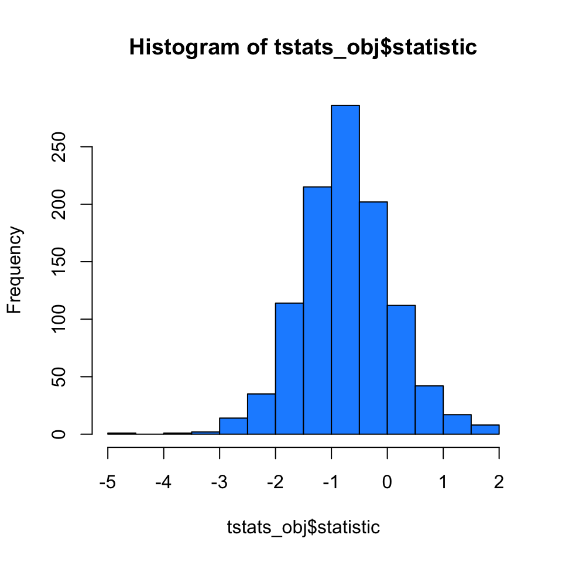

```r
hist(tstats_obj$statistic,col=2)
```

For multi-group comparisons use the F-statistic

```r
fstats_obj = rowFtests(edata,as.factor(pdata$lane.number))
names(fstats_obj)
```

```
## [1] "statistic" "p.value"
```

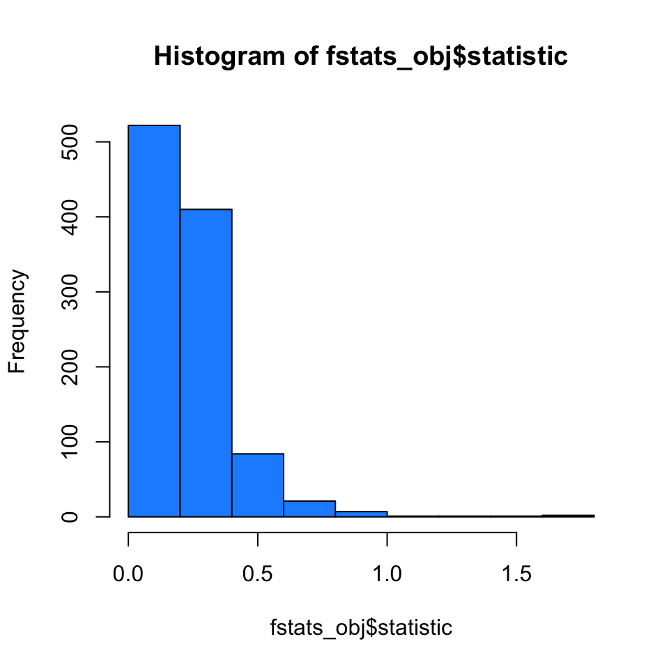

```r
hist(fstats_obj$statistic,col=2)
```

## Fit many statistics with limma

This approach fits many moderated statistics simultaneously

```r
mod = model.matrix(~ pdata$strain)
fit_limma = lmFit(edata,mod)
ebayes_limma = eBayes(fit_limma)
head(ebayes_limma$t)
```

```
##                    (Intercept) pdata$strainDBA/2J
## ENSMUSG00000000131    61.56232         1.48876396
## ENSMUSG00000000149    63.84978        -0.09514821
## ENSMUSG00000000374    63.48896         1.00196514
## ENSMUSG00000000399    60.07990         0.19593890
## ENSMUSG00000000532    64.97678         0.80640805
## ENSMUSG00000000605    68.18274         0.79136446
```

If the model is unadjusted you get the moderated version of the statistic from `rowttests`

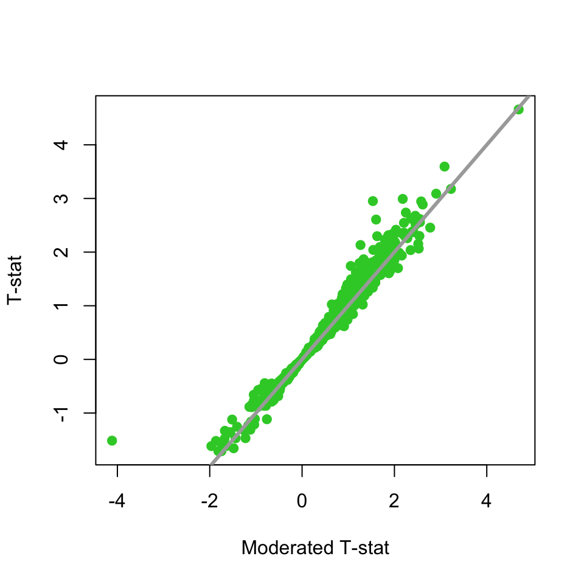

```r
plot(ebayes_limma$t[,2],-tstats_obj$statistic,col=4,
     xlab="Moderated T-stat",ylab="T-stat")
abline(c(0,1),col="darkgrey",lwd=3)
```

## Fit many adjusted statistics with limma

Here we adjust for the lane number, now the test-statistic for the strain is adjusted for the lane number (a surrogate for a batch effect).

```r
mod_adj = model.matrix(~ pdata$strain + as.factor(pdata$lane.number))
fit_limma_adj = lmFit(edata,mod_adj)
ebayes_limma_adj = eBayes(fit_limma_adj)
head(ebayes_limma_adj$t)
```

```
##                    (Intercept) pdata$strainDBA/2J
## ENSMUSG00000000131    27.42608        0.993341906
## ENSMUSG00000000149    28.30319       -0.302293604
## ENSMUSG00000000374    28.43334        0.684161612
## ENSMUSG00000000399    26.89729       -0.007509614
## ENSMUSG00000000532    29.20894        0.552296098
## ENSMUSG00000000605    30.52908        0.450401742
##                    as.factor(pdata$lane.number)2
## ENSMUSG00000000131                   0.106103723
## ENSMUSG00000000149                   0.283169296
## ENSMUSG00000000374                   0.062660205
## ENSMUSG00000000399                   0.066998156
## ENSMUSG00000000532                  -0.036205851
## ENSMUSG00000000605                   0.001102388
##                    as.factor(pdata$lane.number)3
## ENSMUSG00000000131                    0.04870234
## ENSMUSG00000000149                    0.15268674
## ENSMUSG00000000374                   -0.04788353
## ENSMUSG00000000399                   -0.13957244
## ENSMUSG00000000532                   -0.13080316
## ENSMUSG00000000605                   -0.08760933
##                    as.factor(pdata$lane.number)5
## ENSMUSG00000000131                   0.137709189
## ENSMUSG00000000149                   0.114049004
## ENSMUSG00000000374                  -0.031272733
## ENSMUSG00000000399                   0.156240669
## ENSMUSG00000000532                  -0.007169364
## ENSMUSG00000000605                   0.185393375
##                    as.factor(pdata$lane.number)6
## ENSMUSG00000000131                     0.7274749
## ENSMUSG00000000149                     1.0154366
## ENSMUSG00000000374                     0.5228153
## ENSMUSG00000000399                     0.8271336
## ENSMUSG00000000532                     0.3135213
## ENSMUSG00000000605                     0.4940291
##                    as.factor(pdata$lane.number)7
## ENSMUSG00000000131                    0.41722714
## ENSMUSG00000000149                    0.58175790
## ENSMUSG00000000374                    0.23222225
## ENSMUSG00000000399                    0.05475727
## ENSMUSG00000000532                    0.14890971
## ENSMUSG00000000605                    0.27370736
##                    as.factor(pdata$lane.number)8
## ENSMUSG00000000131                    0.28886043
## ENSMUSG00000000149                    0.39833581
## ENSMUSG00000000374                    0.11020429
## ENSMUSG00000000399                   -0.01182217
## ENSMUSG00000000532                   -0.02978295
## ENSMUSG00000000605                    0.18942807
```

If the model is adjusted you get the moderated version of the statistic but it doesn’t match `rowttests` because it is adjusted

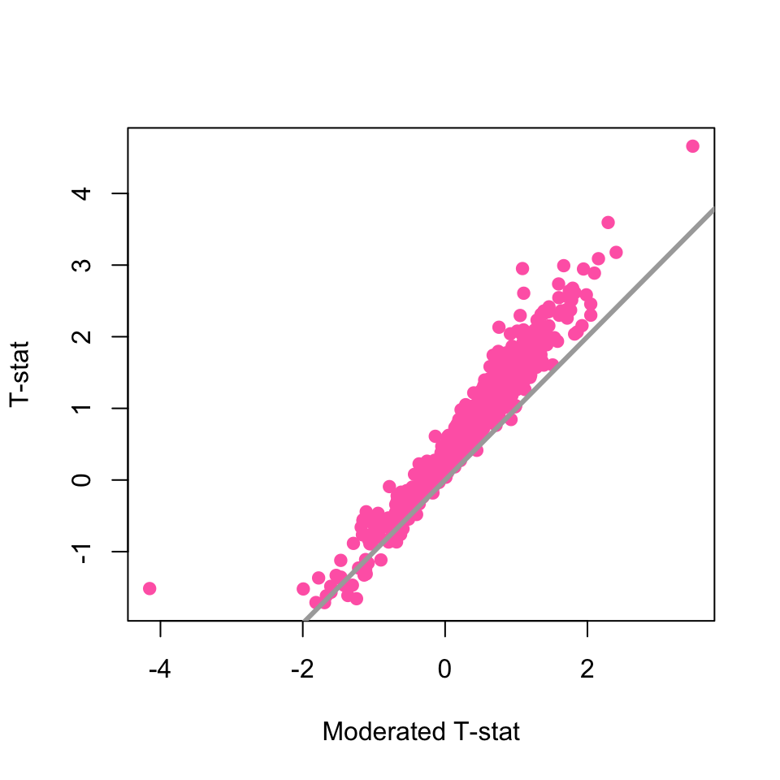

```r
plot(ebayes_limma_adj$t[,2],-tstats_obj$statistic,col=3,
     xlab="Moderated T-stat",ylab="T-stat")
abline(c(0,1),lwd=3,col="darkgrey")
```

## Calculating a nested model comparison with limma

Sometimes we want to compare the null model to the alternative model with some additional covariates. Here we have to know which coefficients we want to test in the alternative model.

Suppose we wanted to find lane effects then we can fit a limma model and find which coefficients belong to the lane variable.

```r
mod_lane = model.matrix(~ as.factor(pdata$lane.number))
fit_limma_lane = lmFit(edata,mod_lane)
ebayes_limma_lane = eBayes(fit_limma_lane)
head(ebayes_limma_lane$t)
```

```
##                    (Intercept) as.factor(pdata$lane.number)2
## ENSMUSG00000000131    29.18101                   0.108054558
## ENSMUSG00000000149    29.75296                   0.288375678
## ENSMUSG00000000374    30.15864                   0.063812283
## ENSMUSG00000000399    28.35119                   0.068229991
## ENSMUSG00000000532    30.94034                  -0.036871536
## ENSMUSG00000000605    32.30420                   0.001122656
##                    as.factor(pdata$lane.number)3
## ENSMUSG00000000131                    0.04959779
## ENSMUSG00000000149                    0.15549405
## ENSMUSG00000000374                   -0.04876393
## ENSMUSG00000000399                   -0.14213864
## ENSMUSG00000000532                   -0.13320812
## ENSMUSG00000000605                   -0.08922013
##                    as.factor(pdata$lane.number)5
## ENSMUSG00000000131                    0.33389895
## ENSMUSG00000000149                    0.06002328
## ENSMUSG00000000374                    0.09926018
## ENSMUSG00000000399                    0.16048443
## ENSMUSG00000000532                    0.09886277
## ENSMUSG00000000605                    0.27882684
##                    as.factor(pdata$lane.number)6
## ENSMUSG00000000131                     0.9451392
## ENSMUSG00000000149                     0.9942322
## ENSMUSG00000000374                     0.6735237
## ENSMUSG00000000399                     0.8558060
## ENSMUSG00000000532                     0.4312304
## ENSMUSG00000000605                     0.5987006
##                    as.factor(pdata$lane.number)7
## ENSMUSG00000000131                    0.62359473
## ENSMUSG00000000149                    0.54476241
## ENSMUSG00000000374                    0.37234955
## ENSMUSG00000000399                    0.05530581
## ENSMUSG00000000532                    0.26062501
## ENSMUSG00000000605                    0.37035652
##                    as.factor(pdata$lane.number)8
## ENSMUSG00000000131                    0.49055391
## ENSMUSG00000000149                    0.35466155
## ENSMUSG00000000374                    0.24588867
## ENSMUSG00000000399                   -0.01369792
## ENSMUSG00000000532                    0.07542578
## ENSMUSG00000000605                    0.28300845
```

Then we can get the F-statistics with `topTable`

```r
top_lane = topTable(ebayes_limma_lane, coef=2:7,
                    number=dim(edata)[1],sort.by="none")
head(top_lane)
```

```
##                    as.factor.pdata.lane.number.2
## ENSMUSG00000000131                  0.0545143060
## ENSMUSG00000000149                  0.1454876148
## ENSMUSG00000000374                  0.0321937582
## ENSMUSG00000000399                  0.0344225239
## ENSMUSG00000000532                 -0.0186019566
## ENSMUSG00000000605                  0.0005663883
##                    as.factor.pdata.lane.number.3
## ENSMUSG00000000131                    0.02502244
## ENSMUSG00000000149                    0.07844787
## ENSMUSG00000000374                   -0.02460175
## ENSMUSG00000000399                   -0.07170997
## ENSMUSG00000000532                   -0.06720446
## ENSMUSG00000000605                   -0.04501220
##                    as.factor.pdata.lane.number.5
## ENSMUSG00000000131                    0.16845444
## ENSMUSG00000000149                    0.03028218
## ENSMUSG00000000374                    0.05007748
## ENSMUSG00000000399                    0.08096556
## ENSMUSG00000000532                    0.04987698
## ENSMUSG00000000605                    0.14067016
##                    as.factor.pdata.lane.number.6
## ENSMUSG00000000131                     0.4768296
## ENSMUSG00000000149                     0.5015973
## ENSMUSG00000000374                     0.3397976
## ENSMUSG00000000399                     0.4317603
## ENSMUSG00000000532                     0.2175589
## ENSMUSG00000000605                     0.3020488
##                    as.factor.pdata.lane.number.7
## ENSMUSG00000000131                    0.31460805
## ENSMUSG00000000149                    0.27483657
## ENSMUSG00000000374                    0.18785304
## ENSMUSG00000000399                    0.02790218
## ENSMUSG00000000532                    0.13148720
## ENSMUSG00000000605                    0.18684754
##                    as.factor.pdata.lane.number.8  AveExpr          F
## ENSMUSG00000000131                    0.24748800 10.59389 0.23962863
## ENSMUSG00000000149                    0.17892932 10.78688 0.23360430
## ENSMUSG00000000374                    0.12405261 10.86015 0.12886955
## ENSMUSG00000000399                   -0.00691070 10.18493 0.21598161
## ENSMUSG00000000532                    0.03805285 11.08784 0.07307893
## ENSMUSG00000000605                    0.14277981 11.62820 0.12134214
##                      P.Value adj.P.Val
## ENSMUSG00000000131 0.9635205 0.9998831
## ENSMUSG00000000149 0.9657594 0.9998831
## ENSMUSG00000000374 0.9927726 0.9998831
## ENSMUSG00000000399 0.9718839 0.9998831
## ENSMUSG00000000532 0.9985087 0.9998831
## ENSMUSG00000000605 0.9938655 0.9998831
```

This is again the moderated version of the F-statistic we saw earlier

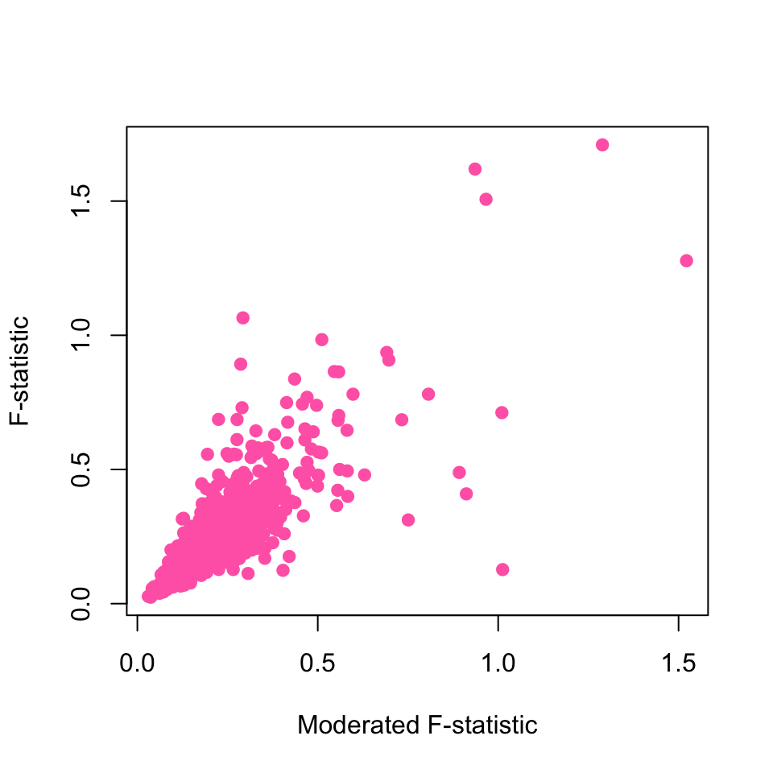

```r
plot(top_lane$F,fstats_obj$statistic,
     xlab="Moderated F-statistic",ylab="F-statistic",col=3)
```

## Calculating a nested comparison with edge

We can also perform the unmoderated nested comparisons in the `edge` package, which also has functions for calculating a more powerful [odp statistic](http://genomine.org/papers/SDL_Biostat_2007.pdf)

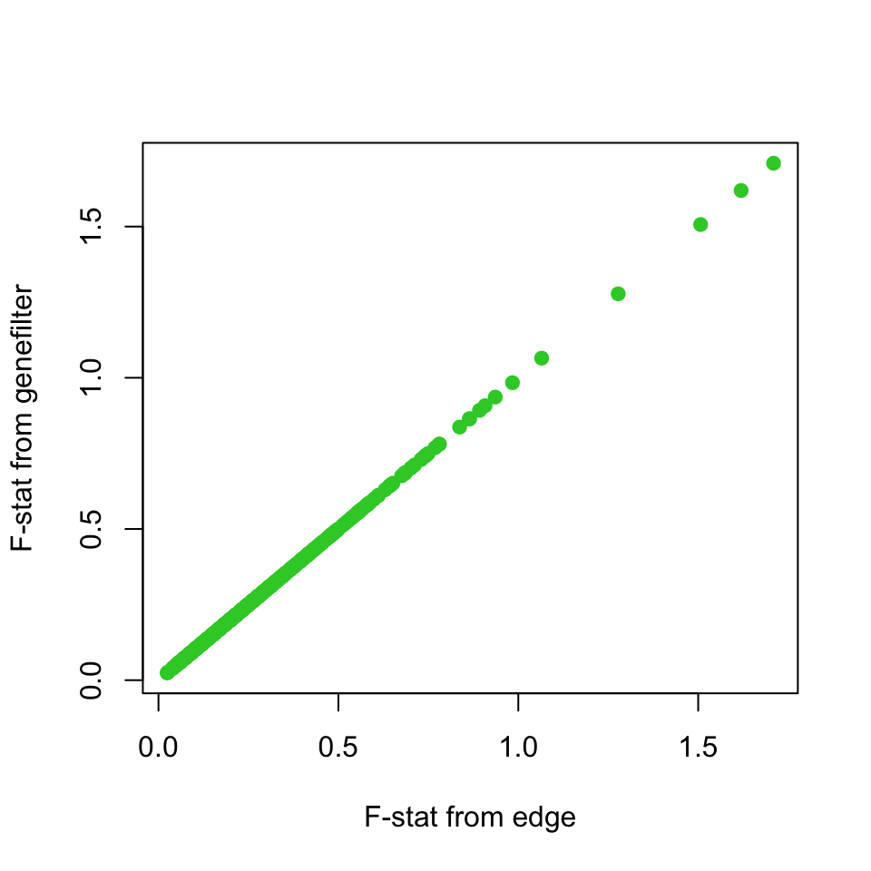

```r
edge_study = build_study(edata, grp = as.factor(pdata$lane.number))
de_obj = lrt(edge_study)
qval = qvalueObj(de_obj)
plot(qval$stat,fstats_obj$statistic,col=4,
      xlab="F-stat from edge",ylab="F-stat from genefilter")
```

We can easily adjust for variables by passing arguments to the `adj.var` variable.

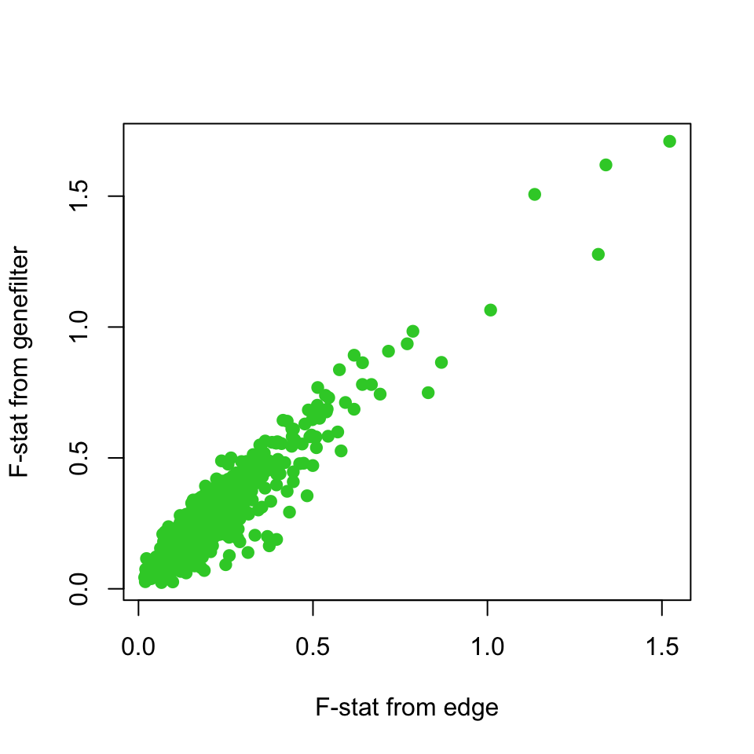

```r
edge_study2 = build_study(edata, grp = as.factor(pdata$lane.number),
                        adj.var=pdata$strain)
de_obj2 = lrt(edge_study2)
qval2 = qvalueObj(de_obj2)
plot(qval2$stat,fstats_obj$statistic,col=4,
      xlab="F-stat from edge",ylab="F-stat from genefilter")
```

## More information

You can find a lot more information on this model fitting strategy in:

- The [limma paper](http://www.bioconductor.org/packages/release/bioc/vignettes/limma/inst/doc/usersguide.pdf)
- The [limma vignette](http://www.bioconductor.org/packages/release/bioc/vignettes/limma/inst/doc/usersguide.pdf)

## Session information

```
##  setting  value
##  version  R version 3.2.1 (2015-06-18)
##  system   x86_64, darwin10.8.0
##  ui       RStudio (0.99.447)
##  language (EN)
##  collate  en_US.UTF-8
##  tz       America/New_York
##
##  package           * version     date
##  acepack             1.3-3.3     2014-11-24
##  annotate            1.46.1      2015-07-11
##  AnnotationDbi     * 1.30.1      2015-04-26
##  assertthat          0.1         2013-12-06
##  BiasedUrn         * 1.06.1      2013-12-29
##  Biobase           * 2.28.0      2015-04-17
##  BiocGenerics      * 0.14.0      2015-04-17
##  BiocInstaller     * 1.18.4      2015-07-22
##  BiocParallel        1.2.20      2015-08-07
##  biomaRt             2.24.0      2015-04-17
##  Biostrings          2.36.3      2015-08-12
##  bitops              1.0-6       2013-08-17
##  bladderbatch      * 1.6.0       2015-08-26
##  broom             * 0.3.7       2015-05-06
##  caTools             1.17.1      2014-09-10
##  cluster             2.0.3       2015-07-21
##  colorspace          1.2-6       2015-03-11
##  corpcor             1.6.8       2015-07-08
##  curl                0.9.2       2015-08-08
##  DBI               * 0.3.1       2014-09-24
##  dendextend        * 1.1.0       2015-07-31
##  DESeq2            * 1.8.1       2015-05-02
##  devtools          * 1.8.0       2015-05-09
##  digest              0.6.8       2014-12-31
##  dplyr             * 0.4.3       2015-09-01
##  edge              * 2.1.0       2015-09-06
##  evaluate            0.7.2       2015-08-13
##  foreign             0.8-66      2015-08-19
##  formatR             1.2         2015-04-21
##  Formula           * 1.2-1       2015-04-07
##  futile.logger       1.4.1       2015-04-20
```

[output cut: 181 more lines]

```
##  Bioconductor
##  Bioconductor
##  CRAN (R 3.2.1)
##  CRAN (R 3.2.0)
##  CRAN (R 3.2.1)
##  Bioconductor
##  CRAN (R 3.2.0)
##  CRAN (R 3.2.2)
##  CRAN (R 3.2.0)
##  CRAN (R 3.2.1)
##  CRAN (R 3.2.2)
##  CRAN (R 3.2.0)
##  Bioconductor
##  CRAN (R 3.2.0)
##  Bioconductor
```

It is also useful to compile the time the document was processed. This document was processed on: 2015-09-06.